# **SkyTrax: Passenger Reviews of Airline Seats**

#### Tidy and wrangle the data

```r
airbus_mods <- c("A300", "A310-300","A319","A320","A321", "A320-200","A330","A330-200","A330-300","A340","A340-300","A340-500","A340-600","A380", "A380-800","A300-600", "A321/A320", "Airbus","AIRBIS")

boeing_mods <- c("B737-900", "B767", "B767-300", "B777", "B777-200", "B777-200LR", "B777-200ER", "B777-300", "B777-300ER", "B777-300", "B757-200", "B747-300", "Boeing747", "B777-300ER", "B747-400", "B757", "B757-200","B777-300W", "Boeing")

seats_tidy <- seats %>%
              select(-link, -title, -author, -date_flown, -type_traveller, -content, -power_supply_rating, -seat_storage_rating) %>%
              separate(col = "aircraft", c("aircraft_make", "aircraft_model"), sep = " ") %>%
              mutate(aircraft_model = ifelse(is.na(aircraft_model), aircraft_make, aircraft_model)) %>%
              mutate(aircraft_make = ifelse(aircraft_make %in% airbus_mods, "AIRBUS", aircraft_make)) %>%
              mutate(aircraft_make = ifelse(aircraft_make %in% boeing_mods, "BOEING", aircraft_make)) %>%
              filter(aircraft_make %in% c("AIRBUS", "BOEING"))

seats_tidy$airline_name <- str_replace_all(seats_tidy$airline_name,"-"," ")
seats_tidy$airline_name <- toupper(seats_tidy$airline_name)

seats_tidy$aircraft_model <- str_replace_all(seats_tidy$aircraft_model,"B","")
seats_tidy$aircraft_model <- str_replace_all(seats_tidy$aircraft_model,"ER","")
seats_tidy$aircraft_model <- str_replace_all(seats_tidy$aircraft_model,"LR","")
seats_tidy$aircraft_model <- str_remove(seats_tidy$aircraft_model, "-.*")
seats_tidy$aircraft_model <- str_remove(seats_tidy$aircraft_model, "/.*")
seats_tidy$seat_layout <- str_replace_all(seats_tidy$seat_layout,"-","x")

glimpse(seats_tidy)
```

```
## Rows: 1,226
## Columns: 14
## $ airline_name        <chr> "AEGEAN AIRLINES", "AEGEAN AIRLINES", "AER LINGUS…
## $ author_country      <chr> "United Kingdom", "United Kingdom", "United State…
## $ date                <date> 2015-07-20, 2013-01-21, 2015-07-07, 2010-10-22, …
## $ aircraft_make       <chr> "AIRBUS", "AIRBUS", "AIRBUS", "AIRBUS", "BOEING",…
## $ aircraft_model      <chr> "A320", "A320", "A330", "A330", "737", "777", "A3…
## $ seat_layout         <chr> "3x3", "3x3", "2x4x2", "2x4x2", "3x3", "2x4x2", "…
## $ cabin_flown         <chr> "Economy", "Economy", "Economy", "Economy", "Econ…
## $ overall_rating      <dbl> 10, 9, 6, 5, 1, 9, 6, 4, 7, 9, 1, 7, 1, 2, 8, 3, …
## $ seat_legroom_rating <dbl> 4, 4, 3, 2, 1, 5, 4, 2, 3, 5, 1, 3, 1, 1, 4, 1, 2…
## $ seat_recline_rating <dbl> 4, 4, 3, 3, 1, 3, 4, 1, 3, 5, 3, 3, 1, 2, 4, 2, 2…
## $ seat_width_rating   <dbl> 4, 4, 3, 3, 1, 5, 4, 3, 3, 4, 3, 3, 3, 2, 3, 2, 2…
## $ aisle_space_rating  <dbl> 5, 4, 3, 3, 2, 5, 3, 2, 4, 3, 1, 3, 1, 1, 4, 2, 3…
## $ viewing_tv_rating   <dbl> 4, 4, 3, 4, 1, 5, 3, 0, 4, 0, 2, 3, 2, 2, 4, 2, 1…
## $ recommended         <dbl> 1, 1, 1, 0, 1, 1, 1, 0, 1, 1, 0, 1, 0, 0, 1, 0, 0…
```

## QUESTION 1:

### Which airlines are the most frequently rated and which shows the best Overall Rating performance?

#### The 12 most frequently rated airlines

```r
by_airline <- seats_tidy %>% group_by(airline_name) %>%
                             summarise(num_of_reviews = n(),
                                       mean_overall_rating = mean(overall_rating),
                                       median_overall_rating = median(overall_rating),
                                       sdev = sd(overall_rating)) %>%
                             filter(num_of_reviews >= 39) %>%
                             arrange(desc(num_of_reviews))
by_airline
```

```
## # A tibble: 12 x 5
##    airline_name       num_of_reviews mean_overall_rati… median_overall_ra…  sdev
##    <chr>                       <int>              <dbl>              <dbl> <dbl>
##  1 BRITISH AIRWAYS                86               4.16                4    2.70
##  2 EMIRATES                       83               3.88                3    2.62
##  3 CATHAY PACIFIC AI…             75               4.15                3    3.25
##  4 VIRGIN ATLANTIC A…             75               3.29                2    2.69
##  5 AIR FRANCE                     64               3.42                3    2.85
##  6 LUFTHANSA                      64               3.66                3    2.98
##  7 QANTAS AIRWAYS                 64               5.56                5.5  3.09
##  8 SINGAPORE AIRLINES             54               5.46                6    2.96
##  9 ETIHAD AIRWAYS                 46               2.83                1    2.37
## 10 QATAR AIRWAYS                  45               7.47                9    2.64
## 11 AMERICAN AIRLINES              44               2.32                1.5  1.60
## 12 KLM ROYAL DUTCH A…             39               2.85                2    2.23
```

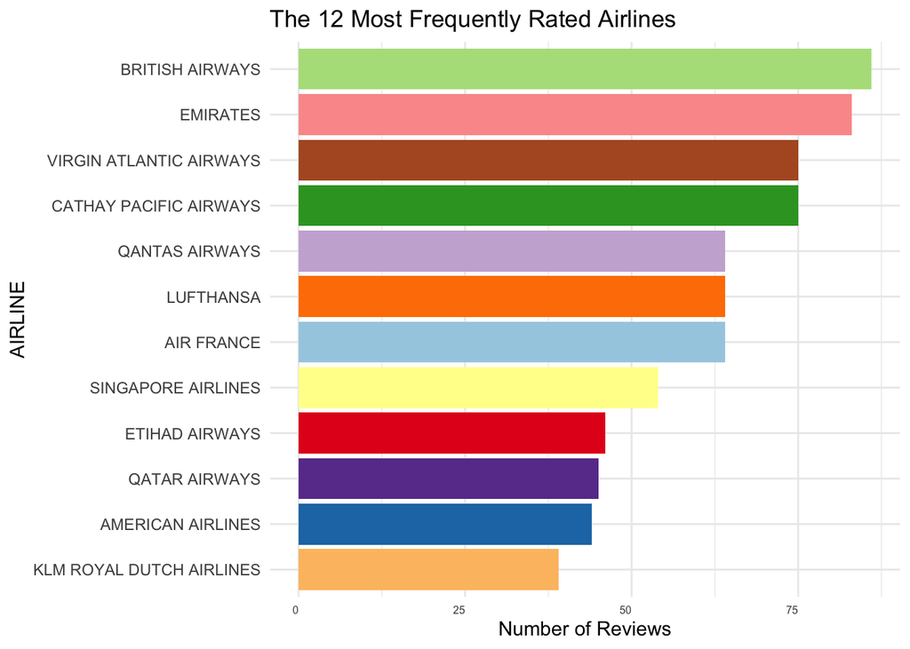

```r
by_airline %>% ggplot(aes(x = reorder(airline_name,num_of_reviews), y = num_of_reviews, fill = airline_name))+
               geom_bar(stat ="identity") +
               theme_minimal() +
               theme(axis.text.x=element_text(size=6, hjust=1),
                     axis.ticks.x=element_blank(),
                     legend.position="none") +
               scale_fill_brewer(palette = "Paired") +
               coord_flip() +
               labs(title = "The 12 Most Frequently Rated Airlines",
                    x = "AIRLINE",
                    y = "Number of Reviews")
```

## QUESTION 2:

### Distribution of overall rating for top 12 most frequently rated airlines

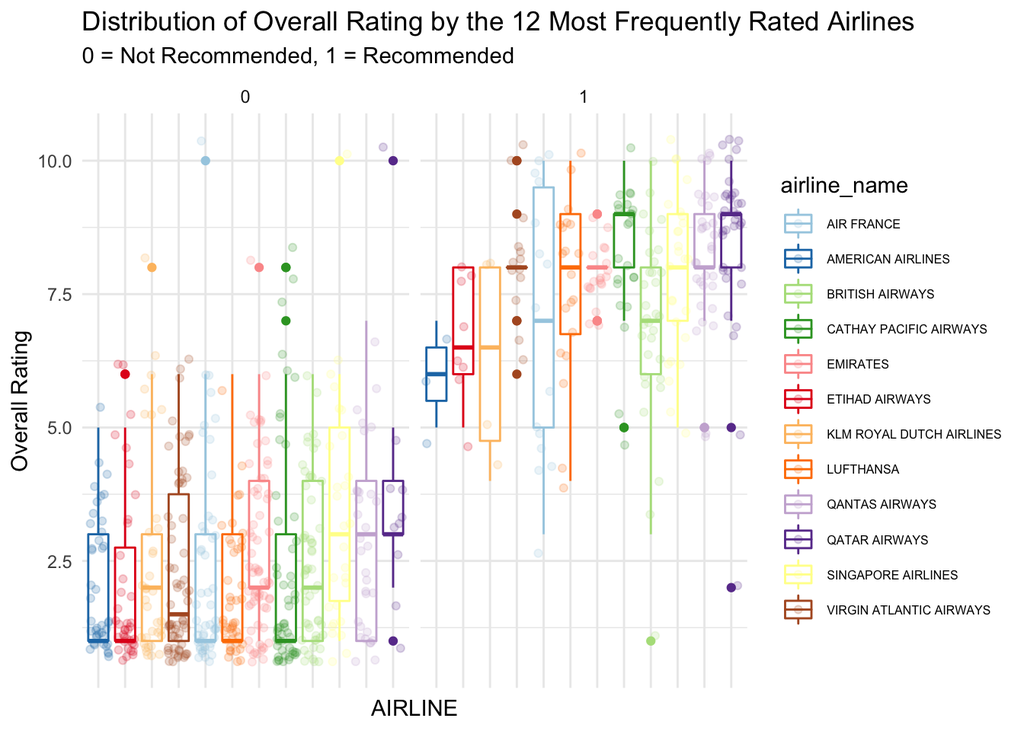

```r
most_rated_airlines <- seats_tidy %>% filter(airline_name %in% c("AIR FRANCE","AMERICAN AIRLINES","BRITISH AIRWAYS","CATHAY PACIFIC AIRWAYS","EMIRATES","ETIHAD AIRWAYS","LUFTHANSA","QANTAS AIRWAYS","QATAR AIRWAYS","SINGAPORE AIRLINES","VIRGIN ATLANTIC AIRWAYS", "KLM ROYAL DUTCH AIRLINES"))

most_rated_airlines %>% ggplot(aes( x = reorder(airline_name, overall_rating), y = overall_rating, colour = airline_name))+
                        geom_boxplot() +
                        geom_jitter(alpha = 0.2) +
                        facet_wrap(recommended~.) +
                        theme_minimal() +
                        theme(axis.text.x=element_blank(), axis.ticks.x=element_blank(), legend.text = element_text(size=6)) +
                        scale_colour_brewer(palette = "Paired") +
                        labs(title = "Distribution of Overall Rating by the 12 Most Frequently Rated Airlines",
                             subtitle = "0 = Not Recommended, 1 = Recommended",
                             x = "AIRLINE",
                             y = "Overall Rating")
```

## QUESTION 3:

#### Calculate the mean of the category ratings

```r
most_rated_airlines <- most_rated_airlines %>% filter(!is.na(viewing_tv_rating)) %>%
              rowwise() %>%
              mutate(mean_cat_rating = mean(seat_legroom_rating:viewing_tv_rating))

glimpse(most_rated_airlines)
```

```
## Rows: 735
## Columns: 15
## Rowwise:
## $ airline_name        <chr> "AIR FRANCE", "AIR FRANCE", "AIR FRANCE", "AIR FR…
## $ author_country      <chr> "Singapore", "United States", "United States", "U…
## $ date                <date> 2015-06-30, 2015-06-11, 2015-05-10, 2015-05-10, …
## $ aircraft_make       <chr> "BOEING", "BOEING", "AIRBUS", "AIRBUS", "BOEING",…
## $ aircraft_model      <chr> "777", "777", "A380", "A380", "777", "777", "777"…
## $ seat_layout         <chr> "3x4x3", "3x4x3", "2x3x2", "2x4x2", "2x4x2", "3x4…
## $ cabin_flown         <chr> "Economy", "Economy", "Premium Economy", "Premium…
## $ overall_rating      <dbl> 6, 10, 9, 1, 4, 8, 1, 6, 2, 1, 10, 1, 3, 6, 3, 10…
## $ seat_legroom_rating <dbl> 2, 5, 5, 2, 4, 4, 3, 3, 3, 1, 5, 1, 1, 5, 4, 5, 5…
## $ seat_recline_rating <dbl> 3, 4, 4, 1, 1, 3, 1, 2, 1, 1, 3, 1, 2, 1, 1, 1, 5…
## $ seat_width_rating   <dbl> 2, 5, 5, 3, 4, 4, 1, 3, 1, 1, 5, 1, 2, 3, 3, 1, 5…
## $ aisle_space_rating  <dbl> 5, 5, 4, 3, 3, 4, 1, 3, 2, 1, 5, 1, 1, 3, 3, 3, 5…
## $ viewing_tv_rating   <dbl> 5, 5, 3, 2, 4, 5, 1, 1, 4, 2, 5, 1, 2, 1, 3, 1, 5…
## $ recommended         <dbl> 0, 1, 1, 0, 1, 1, 0, 0, 0, 0, 1, 0, 0, 0, 0, 0, 1…
## $ mean_cat_rating     <dbl> 3.5, 5.0, 4.0, 2.0, 4.0, 4.5, 2.0, 2.0, 3.5, 1.5,…
```

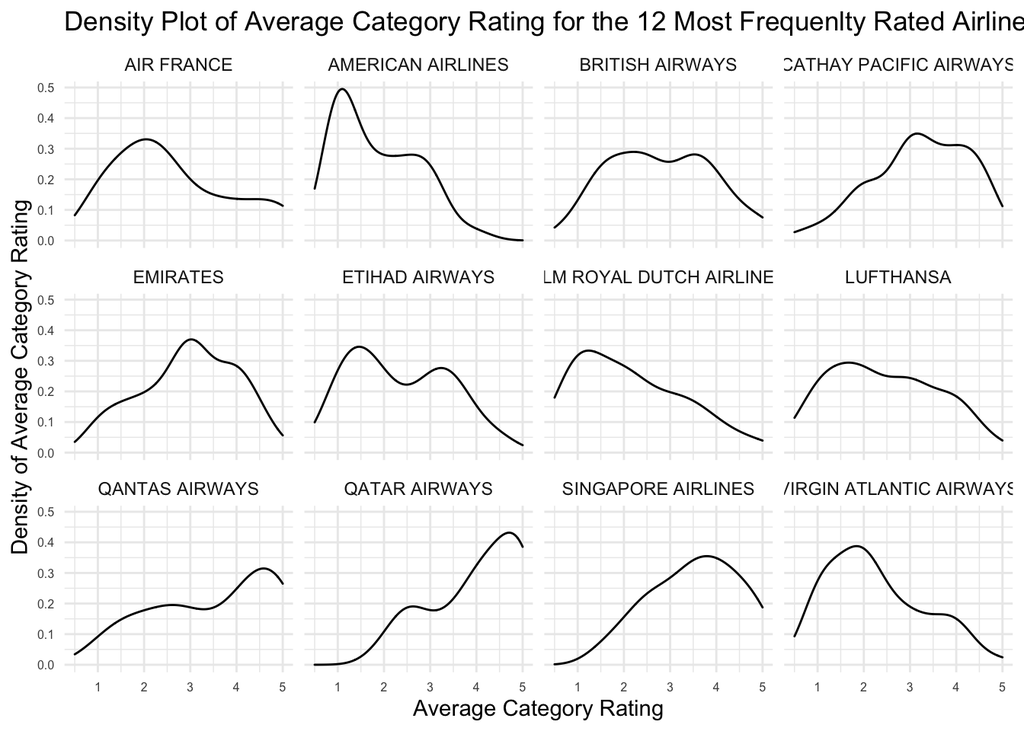

```r
most_rated_airlines %>% ggplot(aes(mean_cat_rating)) +
                        geom_density() +
                        facet_wrap(.~airline_name) +
                        theme_minimal() +
                        theme(axis.text.x=element_text(size=6),axis.text.y=element_text(size=6)) +
                        labs(title = "Density Plot of Average Category Rating for the 12 Most Frequenlty Rated Airlines",
                             x = "Average Category Rating",
                             y = "Density of Average Category Rating")
```

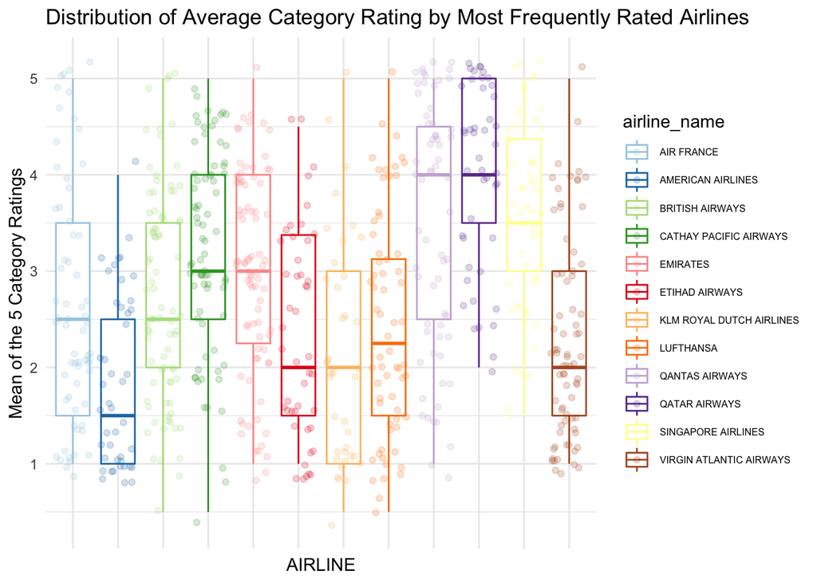

```r
most_rated_airlines %>% ggplot(aes( x = airline_name, y = mean_cat_rating, color = airline_name))+
                        geom_boxplot() +
                        geom_jitter(alpha = 0.2) +
                        theme_minimal() +
                        theme(axis.text.x=element_blank(), axis.ticks.x=element_blank(), legend.text = element_text(size=6)) +
                        scale_color_brewer(palette = "Paired") +
                        labs(title = "Distribution of Average Category Rating by Most Frequently Rated Airlines",
                             x = "AIRLINE",
                             y = "Mean of the 5 Category Ratings")
```

## QUESTION 4:

### Distribtution of overall rating variable by aircraft make

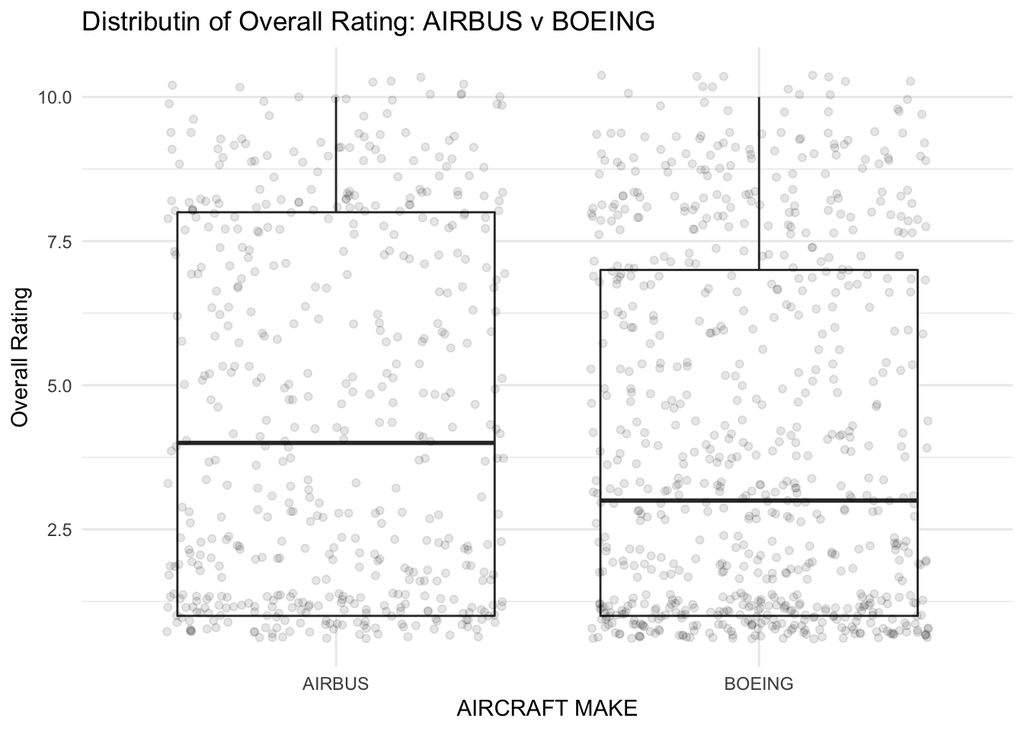

```r
seats_tidy %>% ggplot(aes( x = aircraft_make, y = overall_rating))+
               geom_boxplot() +
               geom_jitter(alpha = 0.1) +
               theme_minimal() +
               labs(title = "Distributin of Overall Rating: AIRBUS v BOEING",
                    x = "AIRCRAFT MAKE",
                    y = "Overall Rating")
```

## QUESTION 5:

### Distribtution of overall rating variable by aircraft modlel

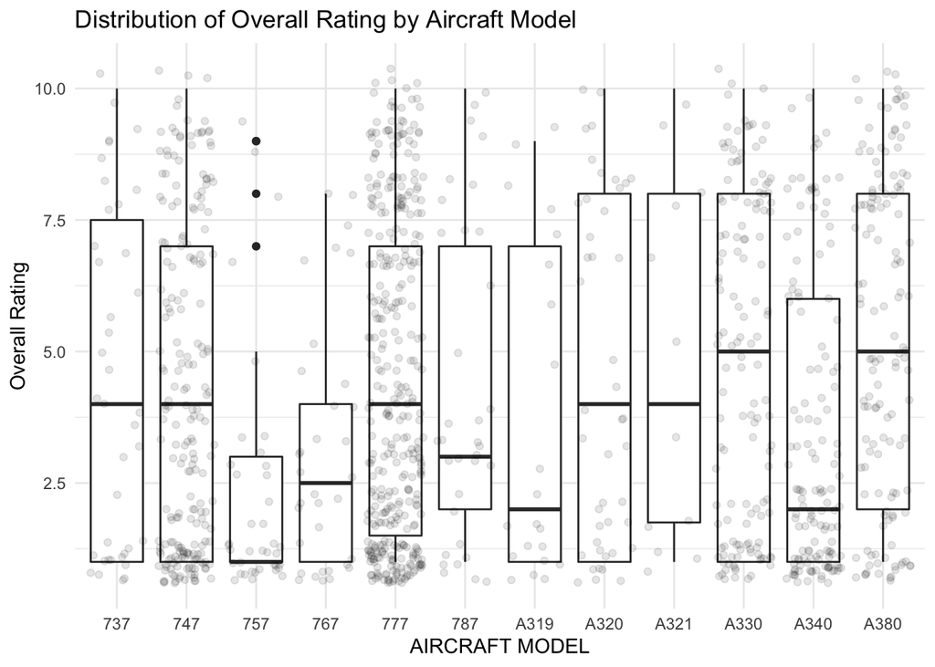

```r
seats_tidy %>% filter(aircraft_model %in% c("737","747","757","767","777","787","A319","A320","A321","A330","A340","A380")) %>%
               ggplot(aes( x = aircraft_model, y = overall_rating, group = aircraft_model))+
               geom_boxplot() +
               geom_jitter(alpha = 0.1) +
               theme_minimal() +
               labs(title = "Distribution of Overall Rating by Aircraft Model",
                    x = "AIRCRAFT MODEL",
                    y = "Overall Rating")
```

## REFERENCES

# Plots

## Which airlines are the most frequently rated?

A bar chart may be used to display the airlines with the highest numbers of reviews. The key aesthetics will be variables airline_name and a new variable: no_of_reviews. The geom function will be geom_bar.

## How does overall rating vary amoungst the most frequently rated airlines?

A box-plot can show the distribution of the values. Plan to use a series of side-by-side box-plots represetning the airlines. The variables airline_name and overall_rating will be the aesthetics. Functions geom_boxplot() and geom_jitter() give the box-plot and overly the data points as well.

## How is the average category rating distributed across the most frequently rated airlines?

A histogram or density plot may be used to show this distribution. A new variable for the average value of the category ratings must be calculated. This will be plotted using geom_density() function and the plot faceted by airline_name to show the distribution for the twelve most frequently rated airlines.

## Which aircraft models show the best overall rating results?

A box-plot with variables overall_rating and aircraft_model as the aesthetics.